# Exercises day 2: Logistic regression

Authors

Guy-Alain Schnidrig (VPHI)

Filipe Miguel Maximiano Alves de Sousa (VPHI)

Eleftheria Michalopoulou (ISPM)

Beatriz Vidondo (VPHI)

Ben Spycher (ISPM)

### Information

These are the exercises for the [Linear and Logistic Regression in R](https://zuw.me/kurse/dt.php?kid=4476) course of the [Public Health Sciences Course Program](https://www.medizin.unibe.ch/studies/study_programs/phs_course_program) at the [University of Bern](https://www.unibe.ch/).

We will use the Dataset “nocardia.csv” (modified), from Dohoo,I., Martin, W. & Stryhn,H., 2010. Veterinary Epidemiologic Research, Second Edition.

This is a case-control study of mastitis caused by Nocardia spp., from 54 case herds and 54 control herds (outcome), with the predictors related to the management of the cows during the dry period.

Our outcome is the number of herds where there are mastitis caused by Nocardia spp. and our explanatory variables are the percentage of cows in the heard treated with dry-cow treatment and the use of neomycin-based and cloxacillin-based dry-cow products for the dry-cow treatments.

The following are the variables:

- “casecont”: case or control status of the herd (outcome)
- “dcpct”: percentage of cows treated with dry-cow treatment
- “dneo”: use of neomycin-based dry-cow products in the last year (yes/no)
- “dclox”: use of cloxacillin-based dry-cow products in the last year (yes/no)

# Logistic regression

## Load data

Load “nocardia_updated.csv” data using the function “read_csv2()”. Do not forget to define first the working directory from where you can upload the data, using the function “setwd()”.

```r
#set the working directory
#setwd("H:/Aulas/PHS/Regression course/Logistic regression exercises")

# Load the csv file
CC_noccardia <- read_csv2("../data/nocardia_updated.csv")
```

```
ℹ Using "','" as decimal and "'.'" as grouping mark. Use `read_delim()` for more control.
```

### Exercise 1: variables

Use `str()` to display the structure of the data and `head()` to display the first 10 rows of the data.

```r
str(CC_noccardia)
```

```
spc_tbl_ [108 × 5] (S3: spec_tbl_df/tbl_df/tbl/data.frame)
 $ id      : num [1:108] 1 2 3 4 5 6 7 8 9 10 ...
 $ casecont: num [1:108] 0 0 0 0 0 0 0 0 0 0 ...
 $ dcpct   : num [1:108] 0 100 25 1 100 0 0 25 100 14 ...
 $ dneo    : num [1:108] 0 1 0 0 0 0 0 1 0 1 ...
 $ dclox   : num [1:108] 0 0 0 0 1 0 0 1 1 0 ...
 - attr(*, "spec")=
  .. cols(
  ..   id = col_double(),
  ..   casecont = col_double(),
  ..   dcpct = col_double(),
  ..   dneo = col_double(),
  ..   dclox = col_double()
  .. )
 - attr(*, "problems")=<externalptr>
```

```r
CC_noccardia %>%
  head(10) %>%
  kable()
```

| id | casecont | dcpct | dneo | dclox |
| --- | --- | --- | --- | --- |
| 1 | 0 | 0 | 0 | 0 |
| 2 | 0 | 100 | 1 | 0 |
| 3 | 0 | 25 | 0 | 0 |
| 4 | 0 | 1 | 0 | 0 |
| 5 | 0 | 100 | 0 | 1 |
| 6 | 0 | 0 | 0 | 0 |
| 7 | 0 | 0 | 0 | 0 |
| 8 | 0 | 25 | 1 | 1 |
| 9 | 0 | 100 | 0 | 1 |
| 10 | 0 | 14 | 1 | 0 |

### Questions:

- Which types of variables (data types) do we have?
- Are the stored in an appropriate format in R?

Transform to factors the variables “casecont”, “dneo” and “dclox”.

To facilitate the interpretation, change in “dneo” and “dclox” the values 0 to “No” and the values 1 to “Yes” respectively and in “casecont” the values 0 and 1 to “Control” and “Case”, respectively.

You can use the functions “mutate()” and “factor()”, defining then the levels (0,1) and the labels (“Yes” and “No”) and view again some rows of the data

```r
#specifiy the following variables as factor
CC_noccardia<- CC_noccardia %>%
  mutate(dneo = factor(dneo, levels=c(0, 1), labels=c("No", "Yes")),
         dclox = factor(dclox, levels=c(0, 1), labels=c("No", "Yes")),
         casecont = factor(casecont, levels=c(0, 1), labels=c("Control", "Case")))

# CC_noccardia$dneo<-as.factor(CC_noccardia$dneo)
# CC_noccardia$dclox<-as.factor(CC_noccardia$dclox)
# CC_noccardia$casecont<-as.factor(CC_noccardia$casecont)

CC_noccardia %>%
  head() %>%
  kable()
```

| id | casecont | dcpct | dneo | dclox |
| --- | --- | --- | --- | --- |
| 1 | Control | 0 | No | No |
| 2 | Control | 100 | Yes | No |
| 3 | Control | 25 | No | No |
| 4 | Control | 1 | No | No |
| 5 | Control | 100 | No | Yes |
| 6 | Control | 0 | No | No |

## Exploratory analyses

### Exercise 2

Using the functions “tabpct()” and “table()” from the package `epiDisplay`, produce 2*2 tables for casecont/dneo & casecont/dclox.

```
Original table
                     CC_noccardia$dclox
CC_noccardia$casecont   No  Yes  Total
              Control   35   19     54
              Case      46    8     54
              Total     81   27    108

Row percent
                     CC_noccardia$dclox
CC_noccardia$casecont      No     Yes  Total
              Control      35      19     54
                       (64.8)  (35.2)  (100)
              Case         46       8     54
                       (85.2)  (14.8)  (100)

Column percent
                     CC_noccardia$dclox
CC_noccardia$casecont  No       %  Yes       %
              Control  35  (43.2)   19  (70.4)
              Case     46  (56.8)    8  (29.6)
              Total    81   (100)   27   (100)
```

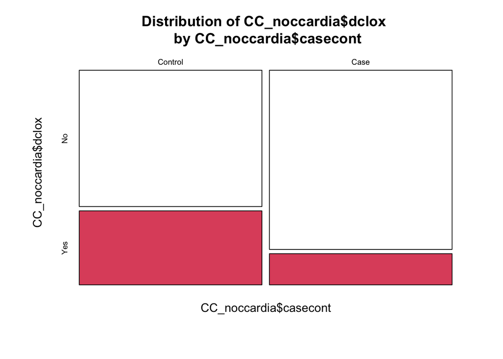

```r
#2*2 tables
tabpct(CC_noccardia$casecont, CC_noccardia$dclox)
```

```
Original table
                     CC_noccardia$dneo
CC_noccardia$casecont   No  Yes  Total
              Control   29   25     54
              Case       5   49     54
              Total     34   74    108

Row percent
                     CC_noccardia$dneo
CC_noccardia$casecont      No     Yes  Total
              Control      29      25     54
                       (53.7)  (46.3)  (100)
              Case          5      49     54
                        (9.3)  (90.7)  (100)

Column percent
                     CC_noccardia$dneo
CC_noccardia$casecont  No       %  Yes       %
              Control  29  (85.3)   25  (33.8)
              Case      5  (14.7)   49  (66.2)
              Total    34   (100)   74   (100)
```

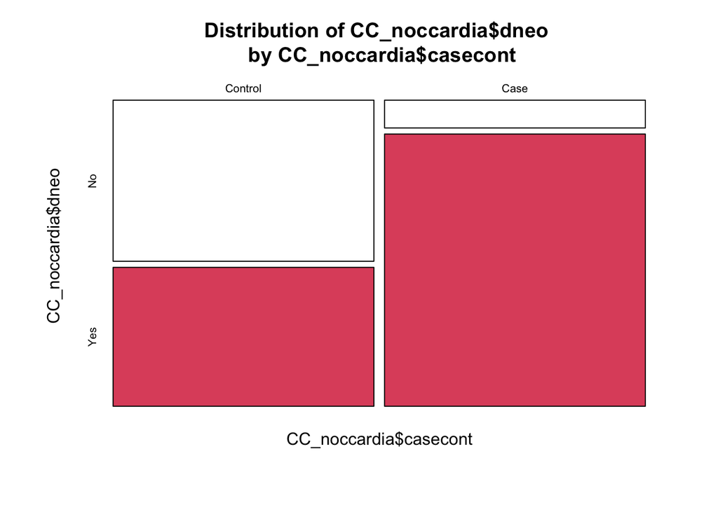

```r
tabpct(CC_noccardia$casecont, CC_noccardia$dneo)
```

### Questions:

- In are the apparent associations more compatible with a harmful or protective effect of these exposures?
- Considering that this is a case-control study which presentation is more meaningful, row or column percentages?

Now use the function “cdplot()” to plot display changes in the conditional distribution of case/control status according to the dcpct?

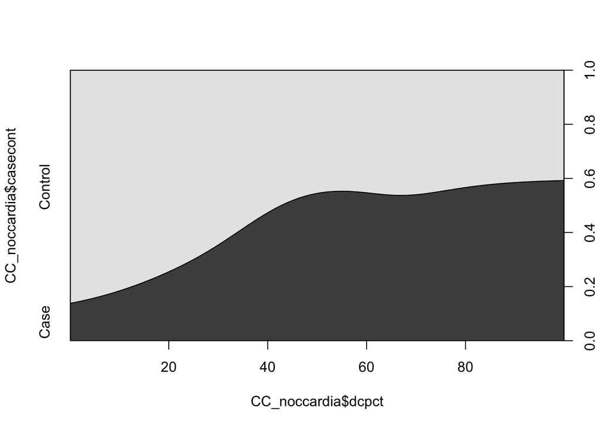

```r
cdplot(CC_noccardia$casecont ~ CC_noccardia$dcpct)
```

- How do you interpret this?

### Exercise 3: variable investigation and interpretation of coefficients (dichotomous)

Use the glm() function to see the effect of the explanatory variable “dneo”. Choose family=binomial within the glm() function, which tells R that we want to fit logistic regression.

After fiting the model, calculate the 95%-confidence Intervals (CI) of the estimates, using the function “confint.default(”model”)“.

To interpret the result, reflect on the type of explanatory variable that we are using in this example.

```r
mod1 <- glm(casecont ~ dneo,family = binomial(link="logit"), data = CC_noccardia)
summary(mod1)
```

```
Call:
glm(formula = casecont ~ dneo, family = binomial(link = "logit"),
    data = CC_noccardia)

Deviance Residuals:
   Min      1Q  Median      3Q     Max
-1.473  -0.564   0.172   0.908   1.958

Coefficients:
            Estimate Std. Error z value Pr(>|z|)
(Intercept)  -1.7579     0.4842  -3.630 0.000283 ***
dneoYes       2.4308     0.5430   4.476 7.59e-06 ***
---
Signif. codes:  0 '***' 0.001 '**' 0.01 '*' 0.05 '.' 0.1 ' ' 1

(Dispersion parameter for binomial family taken to be 1)

    Null deviance: 149.72  on 107  degrees of freedom
Residual deviance: 123.05  on 106  degrees of freedom
AIC: 127.05

Number of Fisher Scoring iterations: 4
```

```r
confint.default(mod1)
```

```
                2.5 %     97.5 %
(Intercept) -2.706939 -0.8087764
dneoYes      1.366466  3.4951384
```

```r
tidy(mod1)
```

```
# A tibble: 2 × 5
  term        estimate std.error statistic    p.value
  <chr>          <dbl>     <dbl>     <dbl>      <dbl>
1 (Intercept)    -1.76     0.484     -3.63 0.000283
2 dneoYes         2.43     0.543      4.48 0.00000759
```

### Questions:

- Write out the fitted regression equation.
- How do you interpret the estimated parameter for dneo?
- Which changes would you need to do to make it be easier to interpret?

Exponentiate the parameters in the model

We can get now the odds ratio by exponentiating the estimates of the estimate and of the CI. You can use the functions “exp(coef(”model”))” and the functions “exp(confint.default(”model”))“.

```r
exp(coef(mod1))
```

```
(Intercept)     dneoYes
  0.1724138  11.3680000
```

- How do you now interpret the estimated parameter for dneo?

### Questions:

Evaluate the regression equation for herds treated with neomicyn and transform the result back to the probability scale.

```r
exp(coef(mod1)[1]+coef(mod1)[2]*1) / (1+ (exp(coef(mod1)[1]+coef(mod1)[2]*1)))
```

```
(Intercept)
  0.6621622
```

- What does the resulting number mean?
- Considering this is a case-control study, does this number have a meaningful interpretation
- Assume that the data came from a cohort study and the outcome (mastitis caused by Nocardia spp.) was measured prospectively. What would then be the interpretation of that number?

### Exercise 4: variables investigation and interpretation of coefficients (continuous)

Run a logistic regression including “dcpct” (percentage of cows treated with dry-cow treatments in the herd) as independent variable

```r
mod2 <- glm(casecont ~ dcpct,family = binomial(link="logit"), data = CC_noccardia)
summary(mod2)
```

```
Call:
glm(formula = casecont ~ dcpct, family = binomial(link = "logit"),
    data = CC_noccardia)

Deviance Residuals:
    Min       1Q   Median       3Q      Max
-1.3659  -1.3575   0.1772   0.9999   1.8196

Coefficients:
             Estimate Std. Error z value Pr(>|z|)
(Intercept) -1.462424   0.523052  -2.796  0.00517 **
dcpct        0.018954   0.006018   3.150  0.00163 **
---
Signif. codes:  0 '***' 0.001 '**' 0.01 '*' 0.05 '.' 0.1 ' ' 1

(Dispersion parameter for binomial family taken to be 1)

    Null deviance: 149.72  on 107  degrees of freedom
Residual deviance: 138.15  on 106  degrees of freedom
AIC: 142.15

Number of Fisher Scoring iterations: 4
```

### Questions:

- How do you interpret the estimate value for “dcpct”?
- After exponentiation using exp(coef(“model”)), what does it mean?

```r
exp(coef(mod2))
```

```
(Intercept)       dcpct
  0.2316741   1.0191351
```

- Can you calculate the OR for the development of mastitis due to Nocardia spp. comparing herds where 30% and 60% of the animals are treated with dry treatment? (exp(log(odds(60))-log(odds(30))))

```r
exp((coef(mod2)[1]+coef(mod2)[2]*60) - (coef(mod2)[1]+coef(mod2)[2]*30))
```

```
(Intercept)
   1.765847
```

```r
#or equivalently
exp(30*coef(mod2)[2])
```

```
   dcpct
1.765847
```

### Exercise 5: Confounding

As seen, confounding can be assessed by removing or adding a potential confounding variable from the model and observing changes in the coefficients of the variable of interest.

begining with a univaribal logistic regression model including only “dneo”, sequentially add “dclox” and “dcpct.

Convert the parameters by exponentiating them

```r
mod3 <- glm(casecont ~ dneo,family = binomial, data = CC_noccardia)
summary(mod3)
```

```
Call:
glm(formula = casecont ~ dneo, family = binomial, data = CC_noccardia)

Deviance Residuals:
   Min      1Q  Median      3Q     Max
-1.473  -0.564   0.172   0.908   1.958

Coefficients:
            Estimate Std. Error z value Pr(>|z|)
(Intercept)  -1.7579     0.4842  -3.630 0.000283 ***
dneoYes       2.4308     0.5430   4.476 7.59e-06 ***
---
Signif. codes:  0 '***' 0.001 '**' 0.01 '*' 0.05 '.' 0.1 ' ' 1

(Dispersion parameter for binomial family taken to be 1)

    Null deviance: 149.72  on 107  degrees of freedom
Residual deviance: 123.05  on 106  degrees of freedom
AIC: 127.05

Number of Fisher Scoring iterations: 4
```

```r
mod4 <- glm(casecont ~ dneo+dclox,family = binomial, data = CC_noccardia)
summary(mod4)
```

```
Call:
glm(formula = casecont ~ dneo + dclox, family = binomial, data = CC_noccardia)

Deviance Residuals:
    Min       1Q   Median       3Q      Max
-1.5745  -0.6406   0.2138   0.8268   2.2667

Coefficients:
            Estimate Std. Error z value Pr(>|z|)
(Intercept)  -1.4796     0.5014  -2.951  0.00317 **
dneoYes       2.3774     0.5504   4.319 1.56e-05 ***
dcloxYes     -1.0097     0.5319  -1.898  0.05767 .
---
Signif. codes:  0 '***' 0.001 '**' 0.01 '*' 0.05 '.' 0.1 ' ' 1

(Dispersion parameter for binomial family taken to be 1)

    Null deviance: 149.72  on 107  degrees of freedom
Residual deviance: 119.34  on 105  degrees of freedom
AIC: 125.34

Number of Fisher Scoring iterations: 4
```

```r
mod5 <- glm(casecont ~ dneo+dclox + dcpct,family = binomial, data = CC_noccardia)
summary(mod5)
```

```
Call:
glm(formula = casecont ~ dneo + dclox + dcpct, family = binomial,
    data = CC_noccardia)

Deviance Residuals:
    Min       1Q   Median       3Q      Max
-1.8425  -0.8915   0.1610   0.6361   2.3745

Coefficients:
             Estimate Std. Error z value Pr(>|z|)
(Intercept) -2.984272   0.772196  -3.865 0.000111 ***
dneoYes      2.212564   0.578012   3.828 0.000129 ***
dcloxYes    -1.412516   0.557197  -2.535 0.011243 *
dcpct        0.022668   0.007187   3.154 0.001610 **
---
Signif. codes:  0 '***' 0.001 '**' 0.01 '*' 0.05 '.' 0.1 ' ' 1

(Dispersion parameter for binomial family taken to be 1)

    Null deviance: 149.72  on 107  degrees of freedom
Residual deviance: 107.99  on 104  degrees of freedom
AIC: 115.99

Number of Fisher Scoring iterations: 4
```

```r
exp(coef(mod3))
```

```
(Intercept)     dneoYes
  0.1724138  11.3680000
```

```r
exp(coef(mod4))
```

```
(Intercept)     dneoYes    dcloxYes
  0.2277261  10.7769457   0.3643176
```

```r
exp(coef(mod5))
```

```
(Intercept)     dneoYes    dcloxYes       dcpct
 0.05057629  9.13911806  0.24352979  1.02292712
```

### Questions:

- Do you notice any changes in the ORs suggesting confounding? Explain.

You can also calculate the percentage of change in the estimates of the different variables between the two models e.g. using :

```r
(exp(mod5$coef[2:3])-exp(mod4$coef[2:3]))/exp(mod4$coef[2:3])
```

```
   dneoYes   dcloxYes
-0.1519751 -0.3315454
```

### Exercise 6: Interactions

How would you change model 5 to allow for interaction beteen dneo and dcloxis. Exponentiate the coefficients

```r
mod6 <- glm(casecont ~ dcpct + dneo * dclox, family = binomial, data = CC_noccardia)
summary(mod6)
```

```
Call:
glm(formula = casecont ~ dcpct + dneo * dclox, family = binomial,
    data = CC_noccardia)

Deviance Residuals:
    Min       1Q   Median       3Q      Max
-1.9191  -0.7682   0.1874   0.5876   2.6755

Coefficients:
                  Estimate Std. Error z value Pr(>|z|)
(Intercept)      -3.776896   0.993251  -3.803 0.000143 ***
dcpct             0.022618   0.007723   2.928 0.003406 **
dneoYes           3.184002   0.837199   3.803 0.000143 ***
dcloxYes          0.445705   1.026026   0.434 0.663999
dneoYes:dcloxYes -2.551997   1.205075  -2.118 0.034200 *
---
Signif. codes:  0 '***' 0.001 '**' 0.01 '*' 0.05 '.' 0.1 ' ' 1

(Dispersion parameter for binomial family taken to be 1)

    Null deviance: 149.72  on 107  degrees of freedom
Residual deviance: 103.42  on 103  degrees of freedom
AIC: 113.42

Number of Fisher Scoring iterations: 5
```

```r
exp(coef(mod6))
```

```
     (Intercept)            dcpct          dneoYes         dcloxYes
      0.02289363       1.02287522      24.14318756       1.56159028
dneoYes:dcloxYes
      0.07792589
```

### Questions:

- What are the OR values for the use of neomycin-based products only, cloxacilin-based products only and both together (each time comparing to not receiving any of these products?
- Taking this regression at face value, should cloxacilin-based products be used alone or together with neomycin-based products?
- Thinking about the lecture yesterday and considering the changes in estimates and standard errors between model 5 and 6 do you think model 6 might have a problem? Explain.